# Cluster Analysis on Breakfast Cereal

Ravikiran

05 Nov 2017

```r
rm(list = ls(all=TRUE))
```

# Agenda

- Read the dataset
- Data pre-processing
- Explore the dataset
- Hierarchical Clustering
  - Cluster Visualizion and Evaluation
  - Quality of the clusters
  - Cluster Stability
- Kmeans Clustering
  - Cluster Visualizion and Evaluation
  - Quality of the clusters
  - Cluster Stability

# Problem Description

- In the following Unsupervised Learning activity, we try to cluster various types of breakfast cereal based on their nutritional content.

# Reading & Understanding the Data

- Make sure the dataset is located in your current working directory

```r
# Use the setwd() function to get to the directory where the data is present
cereals_data = read.csv('Cereals.csv', header = T)
```

- Use the str(), summary() functions to get a feel for the dataset.

```r
str(cereals_data)
```

```
## 'data.frame':    77 obs. of  14 variables:
##  $ name    : Factor w/ 77 levels "100%_Bran","100%_Natural_Bran",..: 1 2 3 4 5 6 7 8 9 10 ...
##  $ calories: int  70 120 70 50 110 110 110 130 90 90 ...
##  $ protein : int  4 3 4 4 2 2 2 3 2 3 ...
##  $ fat     : int  1 5 1 0 2 2 0 2 1 0 ...
##  $ sodium  : int  130 15 260 140 200 180 125 210 200 210 ...
##  $ fiber   : num  10 2 9 14 1 1.5 1 2 4 5 ...
##  $ carbo   : num  5 8 7 8 14 10.5 11 18 15 13 ...
##  $ sugars  : int  6 8 5 0 8 10 14 8 6 5 ...
##  $ potass  : int  280 135 320 330 NA 70 30 100 125 190 ...
##  $ vitamins: int  25 0 25 25 25 25 25 25 25 25 ...
##  $ shelf   : int  3 3 3 3 3 1 2 3 1 3 ...
##  $ weight  : num  1 1 1 1 1 1 1 1.33 1 1 ...
##  $ cups    : num  0.33 1 0.33 0.5 0.75 0.75 1 0.75 0.67 0.67 ...
##  $ rating  : num  68.4 34 59.4 93.7 34.4 ...
```

```r
summary(cereals_data)
```

```
##                         name       calories        protein
##  100%_Bran                : 1   Min.   : 50.0   Min.   :1.000
##  100%_Natural_Bran        : 1   1st Qu.:100.0   1st Qu.:2.000
##  All-Bran                 : 1   Median :110.0   Median :3.000
##  All-Bran_with_Extra_Fiber: 1   Mean   :106.9   Mean   :2.545
##  Almond_Delight           : 1   3rd Qu.:110.0   3rd Qu.:3.000
##  Apple_Cinnamon_Cheerios  : 1   Max.   :160.0   Max.   :6.000
##  (Other)                  :71
##       fat            sodium          fiber            carbo
##  Min.   :0.000   Min.   :  0.0   Min.   : 0.000   Min.   : 5.0
##  1st Qu.:0.000   1st Qu.:130.0   1st Qu.: 1.000   1st Qu.:12.0
##  Median :1.000   Median :180.0   Median : 2.000   Median :14.5
##  Mean   :1.013   Mean   :159.7   Mean   : 2.152   Mean   :14.8
##  3rd Qu.:2.000   3rd Qu.:210.0   3rd Qu.: 3.000   3rd Qu.:17.0
##  Max.   :5.000   Max.   :320.0   Max.   :14.000   Max.   :23.0
##                                                   NA's   :1
##      sugars           potass          vitamins          shelf
##  Min.   : 0.000   Min.   : 15.00   Min.   :  0.00   Min.   :1.000
##  1st Qu.: 3.000   1st Qu.: 42.50   1st Qu.: 25.00   1st Qu.:1.000
##  Median : 7.000   Median : 90.00   Median : 25.00   Median :2.000
##  Mean   : 7.026   Mean   : 98.67   Mean   : 28.25   Mean   :2.208
##  3rd Qu.:11.000   3rd Qu.:120.00   3rd Qu.: 25.00   3rd Qu.:3.000
##  Max.   :15.000   Max.   :330.00   Max.   :100.00   Max.   :3.000
##  NA's   :1        NA's   :2
##      weight          cups           rating
##  Min.   :0.50   Min.   :0.250   Min.   :18.04
##  1st Qu.:1.00   1st Qu.:0.670   1st Qu.:33.17
##  Median :1.00   Median :0.750   Median :40.40
##  Mean   :1.03   Mean   :0.821   Mean   :42.67
##  3rd Qu.:1.00   3rd Qu.:1.000   3rd Qu.:50.83
##  Max.   :1.50   Max.   :1.500   Max.   :93.70
##
```

- The dataset has 77 observations of 14 variables
- The column/variable names’ are self explanatory

```r
#See the head and tail of the dataframe
head(cereals_data)
```

```
##                        name calories protein fat sodium fiber carbo sugars
## 1                 100%_Bran       70       4   1    130  10.0   5.0      6
## 2         100%_Natural_Bran      120       3   5     15   2.0   8.0      8
## 3                  All-Bran       70       4   1    260   9.0   7.0      5
## 4 All-Bran_with_Extra_Fiber       50       4   0    140  14.0   8.0      0
## 5            Almond_Delight      110       2   2    200   1.0  14.0      8
## 6   Apple_Cinnamon_Cheerios      110       2   2    180   1.5  10.5     10
##   potass vitamins shelf weight cups   rating
## 1    280       25     3      1 0.33 68.40297
## 2    135        0     3      1 1.00 33.98368
## 3    320       25     3      1 0.33 59.42551
## 4    330       25     3      1 0.50 93.70491
## 5     NA       25     3      1 0.75 34.38484
## 6     70       25     1      1 0.75 29.50954
```

```r
tail(cereals_data)
```

```
##                   name calories protein fat sodium fiber carbo sugars
## 72   Total_Whole_Grain      100       3   1    200     3    16      3
## 73             Triples      110       2   1    250     0    21      3
## 74                Trix      110       1   1    140     0    13     12
## 75          Wheat_Chex      100       3   1    230     3    17      3
## 76            Wheaties      100       3   1    200     3    17      3
## 77 Wheaties_Honey_Gold      110       2   1    200     1    16      8
##    potass vitamins shelf weight cups   rating
## 72    110      100     3      1 1.00 46.65884
## 73     60       25     3      1 0.75 39.10617
## 74     25       25     2      1 1.00 27.75330
## 75    115       25     1      1 0.67 49.78744
## 76    110       25     1      1 1.00 51.59219
## 77     60       25     1      1 0.75 36.18756
```

# Data Pre-processing

- Identify the categorical and numerical attributes appropriately

```r
#Store all column names in variable called 'attr'
attr = colnames(cereals_data)
attr
```

```
##  [1] "name"     "calories" "protein"  "fat"      "sodium"   "fiber"
##  [7] "carbo"    "sugars"   "potass"   "vitamins" "shelf"    "weight"
## [13] "cups"     "rating"
```

```r
#Store all categorical attributes in 'cat_Attr'
cat_Attr = "shelf"

#Now, how to find the numerical attributes?
num_Attr = setdiff(attr, c(cat_Attr, "name"))
num_Attr
```

```
##  [1] "calories" "protein"  "fat"      "sodium"   "fiber"    "carbo"
##  [7] "sugars"   "potass"   "vitamins" "weight"   "cups"     "rating"
```

- Attribute ‘shelf’ is a categorical variable. Lets convert appropriately.

```r
cereals_data$shelf = as.factor(as.character(cereals_data$shelf))

#Now see the structure of the dataframe
str(cereals_data)
```

```
## 'data.frame':    77 obs. of  14 variables:
##  $ name    : Factor w/ 77 levels "100%_Bran","100%_Natural_Bran",..: 1 2 3 4 5 6 7 8 9 10 ...
##  $ calories: int  70 120 70 50 110 110 110 130 90 90 ...
##  $ protein : int  4 3 4 4 2 2 2 3 2 3 ...
##  $ fat     : int  1 5 1 0 2 2 0 2 1 0 ...
##  $ sodium  : int  130 15 260 140 200 180 125 210 200 210 ...
##  $ fiber   : num  10 2 9 14 1 1.5 1 2 4 5 ...
##  $ carbo   : num  5 8 7 8 14 10.5 11 18 15 13 ...
##  $ sugars  : int  6 8 5 0 8 10 14 8 6 5 ...
##  $ potass  : int  280 135 320 330 NA 70 30 100 125 190 ...
##  $ vitamins: int  25 0 25 25 25 25 25 25 25 25 ...
##  $ shelf   : Factor w/ 3 levels "1","2","3": 3 3 3 3 3 1 2 3 1 3 ...
##  $ weight  : num  1 1 1 1 1 1 1 1.33 1 1 ...
##  $ cups    : num  0.33 1 0.33 0.5 0.75 0.75 1 0.75 0.67 0.67 ...
##  $ rating  : num  68.4 34 59.4 93.7 34.4 ...
```

- Convert the names of the breakfast cereals to the row names, as this will later help us in visualising the clusters

```r
rownames(cereals_data) <- cereals_data$name
```

- Drop the name column as it is now just redundant information

```r
#cereals_data <- cereals_data[, -c(colnames(cereals_data) %in% ("name"))]
# (or)
cereals_data$name = NULL
```

- Find the number of missing values and either impute or omit them

```r
sum(is.na(cereals_data))
```

```
## [1] 4
```

- There are 4 missing values in dataset, let’s impute them using the knnImputation() function

```r
library(DMwR)
sum(is.na(cereals_data$shelf))
```

```
## [1] 0
```

```r
cereals_data[,num_Attr] <- knnImputation(cereals_data[,num_Attr], k = 3, scale = T)

sum(is.na(cereals_data))
```

```
## [1] 0
```

```r
#How do you find missing values per column?
colSums(is.na(cereals_data))
```

```
## calories  protein      fat   sodium    fiber    carbo   sugars   potass
##        0        0        0        0        0        0        0        0
## vitamins    shelf   weight     cups   rating
##        0        0        0        0        0
```

- Convert the categorical to dummy variables (converting to numeric attributes by using dummy)

```r
#Make a copy of the dataframe for later use (mixed attributes)
cereals_data_copy = cereals_data

library(dummies)
shelfDummies = data.frame(dummy(cereals_data$shelf))
#Name the new attributes appropriately
names(shelfDummies) = c("Shelf1","Shelf2","Shelf3")
head(shelfDummies)
```

```
##   Shelf1 Shelf2 Shelf3
## 1      0      0      1
## 2      0      0      1
## 3      0      0      1
## 4      0      0      1
## 5      0      0      1
## 6      1      0      0
```

- Remove the original attribute ‘shelf’ and add the newly created dummy variables

```r
cereals_data$shelf = NULL
cereals_data = data.frame(cbind(cereals_data, shelfDummies))
#check the dataframe using head()
head(cereals_data)
```

```
##                           calories protein fat sodium fiber carbo sugars
## 100%_Bran                       70       4   1    130  10.0   5.0      6
## 100%_Natural_Bran              120       3   5     15   2.0   8.0      8
## All-Bran                        70       4   1    260   9.0   7.0      5
## All-Bran_with_Extra_Fiber       50       4   0    140  14.0   8.0      0
## Almond_Delight                 110       2   2    200   1.0  14.0      8
## Apple_Cinnamon_Cheerios        110       2   2    180   1.5  10.5     10
##                              potass vitamins weight cups   rating Shelf1
## 100%_Bran                 280.00000       25      1 0.33 68.40297      0
## 100%_Natural_Bran         135.00000        0      1 1.00 33.98368      0
## All-Bran                  320.00000       25      1 0.33 59.42551      0
## All-Bran_with_Extra_Fiber 330.00000       25      1 0.50 93.70491      0
## Almond_Delight             57.84562       25      1 0.75 34.38484      0
## Apple_Cinnamon_Cheerios    70.00000       25      1 0.75 29.50954      1
##                           Shelf2 Shelf3
## 100%_Bran                      0      1
## 100%_Natural_Bran              0      1
## All-Bran                       0      1
## All-Bran_with_Extra_Fiber      0      1
## Almond_Delight                 0      1
## Apple_Cinnamon_Cheerios        0      0
```

- The data must be scaled, before measuring any type of distance metric as the variables with higher ranges will significantly influence the distance

```r
cereals_data[, num_Attr] =  scale(cereals_data[,num_Attr], center = T, scale = T)
```

# Data exploration

- We can use the fviz_dist() function from the factoextra package, to visualize the distances between the observations

```r
# if install.packages("factoextra") doesn't work, use the following
# if(!require(devtools)) install.packages("devtools")
# devtools::install_github("kassambara/factoextra")

library(factoextra)
```

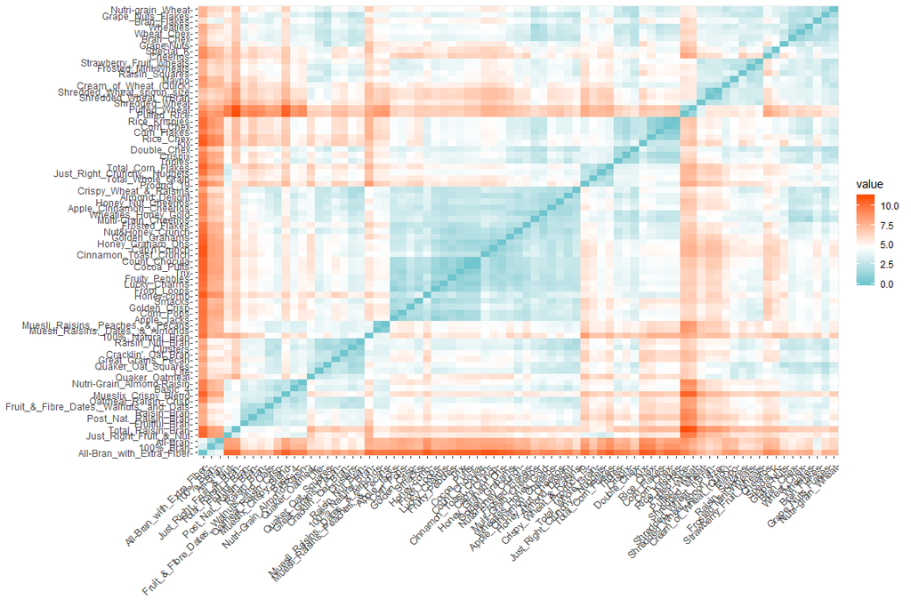

```r
# Use the get_dist() function from the factoexrtra to calculate inter-observation distances
distance <- get_dist(cereals_data)

# The fviz_dist() function plots a visual representation of the inter-observation distances
fviz_dist(distance, gradient = list(low = "#00AFBB", mid = "white", high = "#FC4E07"))
```

```r
# The gradient argument, helps us define the color range for the distance scale
```

# Hierarchical Clustering

### 1. Only numerical attributes - distance measure as ‘Euclidean’

#### Hierarchical Clustering procedure

- Let’s now perform hierarchical clustering using the hclust() function, for which we’ll first need to calculate the distance measures

```r
# We use the euclidean distance measure (all attributes are numerical now)
dist <- dist(cereals_data, method = "euclidean")

hc_fit <- hclust(dist, method = "ward.D2")
#ward.D2 method - find the pair of clusters that leads to minimum increase in total within-cluster variance after merging
```

- We can display the dendrogram for hierarchical clustering, using the plot() function

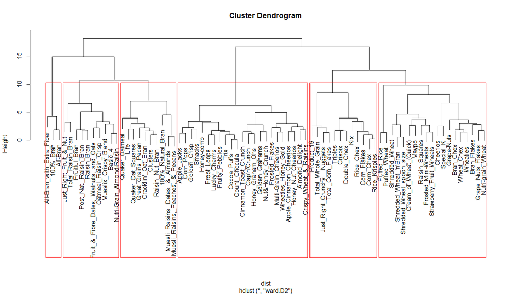

```r
plot(hc_fit)

#Plot clusters being surrounded by a border, using the rect.hclust() function
rect.hclust(hc_fit, k = 6, border = "red")
```

- Cut the tree to 6 clusters, using the cutree() function

```r
points_hc <- cutree(hc_fit, k = 6)

# Store the clusters in a data frame along with the cereals data
cereals_clusts_hc <- cbind(points_hc, cereals_data)

# Have a look at the head of the new data frame
colnames(cereals_clusts_hc)[1] <- "cluster_hc"
head(cereals_clusts_hc)
```

```
##                           cluster_hc   calories    protein         fat
## 100%_Bran                          1 -1.8929836  1.3286071 -0.01290349
## 100%_Natural_Bran                  2  0.6732089  0.4151897  3.96137277
## All-Bran                           1 -1.8929836  1.3286071 -0.01290349
## All-Bran_with_Extra_Fiber          1 -2.9194605  1.3286071 -1.00647256
## Almond_Delight                     3  0.1599704 -0.4982277  0.98066557
## Apple_Cinnamon_Cheerios            3  0.1599704 -0.4982277  0.98066557
##                               sodium       fiber      carbo     sugars
## 100%_Bran                 -0.3539844  3.29284661 -2.5214018 -0.2298253
## 100%_Natural_Bran         -1.7257708 -0.06375361 -1.7487994  0.2293718
## All-Bran                   1.1967306  2.87327158 -2.0063336 -0.4594238
## All-Bran_with_Extra_Fiber -0.2346986  4.97114672 -1.7487994 -1.6074165
## Almond_Delight             0.4810160 -0.48332864 -0.2035948  0.2293718
## Apple_Cinnamon_Cheerios    0.2424445 -0.27354112 -1.1049642  0.6885689
##                               potass   vitamins     weight       cups
## 100%_Bran                  2.6078060 -0.1453172 -0.1967771 -2.1100340
## 100%_Natural_Bran          0.5262315 -1.2642598 -0.1967771  0.7690100
## All-Bran                   3.1820334 -0.1453172 -0.1967771 -2.1100340
## All-Bran_with_Extra_Fiber  3.3255903 -0.1453172 -0.1967771 -1.3795303
## Almond_Delight            -0.5813726 -0.1453172 -0.1967771 -0.3052601
## Apple_Cinnamon_Cheerios   -0.4068881 -0.1453172 -0.1967771 -0.3052601
##                               rating Shelf1 Shelf2 Shelf3
## 100%_Bran                  1.8321876      0      0      1
## 100%_Natural_Bran         -0.6180571      0      0      1
## All-Bran                   1.1930986      0      0      1
## All-Bran_with_Extra_Fiber  3.6333849      0      0      1
## Almond_Delight            -0.5894990      0      0      1
## Apple_Cinnamon_Cheerios   -0.9365625      1      0      0
```

#### Quality of Clusters Created

- Shiloutte width
  - The silhouette width/value is a measure of how similar an object is to its own cluster (cohesion) compared to other clusters (separation) [i.e., intra-cluster cohesion and inter-cluster separation]
  - Ranges from -1 to +1
  - Values closer to 1 means higher quality of the cluster created

```r
library(cluster)
dist = daisy(x = cereals_data, metric = "euclidean")
```

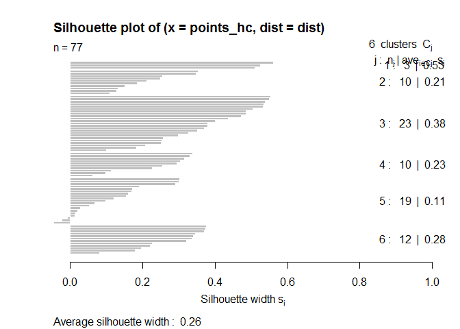

```r
sil_value = silhouette(points_hc, dist = dist)
plot(sil_value)
```

- Try to find the optimal number of clusters where silhouette width would be maximum

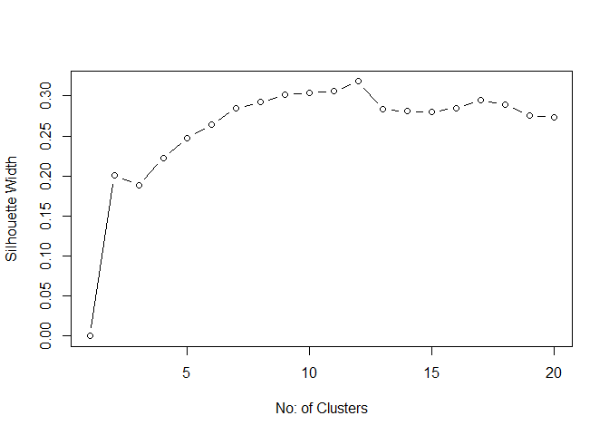

```r
sil_value_hc = 0
for (i in 2:20) {
  points_hc <- cutree(hc_fit, k = i)
  sil_value_hc[i] = mean(silhouette(points_hc, dist = dist)[,3])
}
plot(1:20, sil_value_hc, type = "b", xlab = "No: of Clusters", ylab = "Silhouette Width")
```

#### Cluster Stability

- Using library(fpc) - clusterboot function

```r
library(fpc)
#Input the scaled cereals_data
hclust_stability = clusterboot(cereals_data, clustermethod=hclustCBI, method="ward.D2", k=6, count = FALSE)
hclust_stability
```

```
## * Cluster stability assessment *
## Cluster method:  hclust/cutree
## Full clustering results are given as parameter result
## of the clusterboot object, which also provides further statistics
## of the resampling results.
## Number of resampling runs:  100
##
## Number of clusters found in data:  6
##
##  Clusterwise Jaccard bootstrap (omitting multiple points) mean:
## [1] 0.9142500 0.7192239 0.6631973 0.9719977 0.6017877 0.5684476
## dissolved:
## [1]  9 11 19  0 35 51
## recovered:
## [1] 91 44 28 95 20 25
```

- Analyze the clustering results

```r
clusters = hclust_stability$result$partition
```

- What are the cluster stabiltiy values? Values > 0.85 denote very stable clusters. 0.6 - 0.75 means the clusters show some patterns but needs to be investigated further

```r
#Cluster stability values
hclust_stability$bootmean
```

```
## [1] 0.9142500 0.7192239 0.6631973 0.9719977 0.6017877 0.5684476
```

- How many times the different clusters were dissolved

```r
#Cluster dissolution rate. If maximum Jaccard coefficient < 0.5, that cluster is assumed to be dissolved. Below code shows the number of times each cluster was dissolved. The lower the value, the better.
hclust_stability$bootbrd
```

```
## [1]  9 11 19  0 35 51
```

### 2. Mixed attributes - distance measure as ‘gower’

#### Hierarchical Clustering procedure - mixed attributes

- Let’s now perform same hierarchical clustering using the hclust() function, for mixed datatypes

```r
#Scaling the numeric attributes
cereals_data_copy[,num_Attr] = scale(cereals_data_copy[,num_Attr],scale=T,center=T)

#Calculating gower distance
library(cluster)
gower_dist = daisy(cereals_data_copy,metric = "gower")
gower_dist
```

[output not shown]

[output cut: 3491 more lines]

[output not shown]

```r
class(gower_dist)
```

```
## [1] "dissimilarity" "dist"
```

```r
#Now that you have the distance matrix, do the hclust()
hc_fit_mixed <- hclust(gower_dist, method = "ward.D2")
```

- We can display the dendogram for hierarchical clustering, using the plot() function

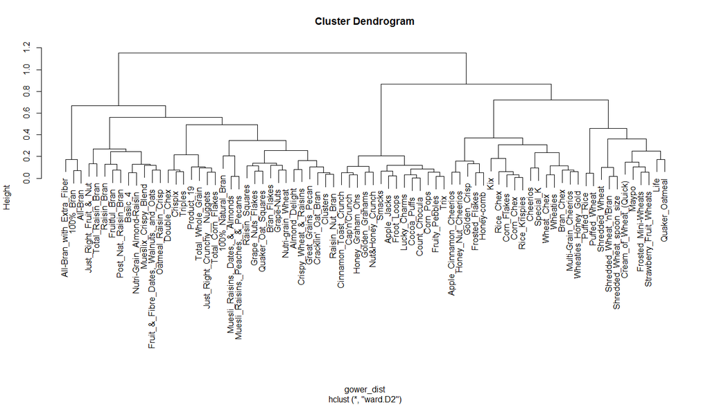

```r
plot(hc_fit_mixed )
```

- Cut the tree to 6 clusters, using the cutree() function

```r
points_hc_mixed <- cutree(hc_fit_mixed , k = 6)

# Store the clusters in a data frame along with the cereals data
cereals_clusts_hc_mixed <- cbind(points_hc_mixed, cereals_data)

# Have a look at the head of the new data frame
colnames(cereals_clusts_hc_mixed)[1] <- "cluster_hc_mixed"
head(cereals_clusts_hc_mixed)
```

```
##                           cluster_hc_mixed   calories    protein
## 100%_Bran                                1 -1.8929836  1.3286071
## 100%_Natural_Bran                        2  0.6732089  0.4151897
## All-Bran                                 1 -1.8929836  1.3286071
## All-Bran_with_Extra_Fiber                1 -2.9194605  1.3286071
## Almond_Delight                           2  0.1599704 -0.4982277
## Apple_Cinnamon_Cheerios                  3  0.1599704 -0.4982277
##                                   fat     sodium       fiber      carbo
## 100%_Bran                 -0.01290349 -0.3539844  3.29284661 -2.5214018
## 100%_Natural_Bran          3.96137277 -1.7257708 -0.06375361 -1.7487994
## All-Bran                  -0.01290349  1.1967306  2.87327158 -2.0063336
## All-Bran_with_Extra_Fiber -1.00647256 -0.2346986  4.97114672 -1.7487994
## Almond_Delight             0.98066557  0.4810160 -0.48332864 -0.2035948
## Apple_Cinnamon_Cheerios    0.98066557  0.2424445 -0.27354112 -1.1049642
##                               sugars     potass   vitamins     weight
## 100%_Bran                 -0.2298253  2.6078060 -0.1453172 -0.1967771
## 100%_Natural_Bran          0.2293718  0.5262315 -1.2642598 -0.1967771
## All-Bran                  -0.4594238  3.1820334 -0.1453172 -0.1967771
## All-Bran_with_Extra_Fiber -1.6074165  3.3255903 -0.1453172 -0.1967771
## Almond_Delight             0.2293718 -0.5813726 -0.1453172 -0.1967771
## Apple_Cinnamon_Cheerios    0.6885689 -0.4068881 -0.1453172 -0.1967771
##                                 cups     rating Shelf1 Shelf2 Shelf3
## 100%_Bran                 -2.1100340  1.8321876      0      0      1
## 100%_Natural_Bran          0.7690100 -0.6180571      0      0      1
## All-Bran                  -2.1100340  1.1930986      0      0      1
## All-Bran_with_Extra_Fiber -1.3795303  3.6333849      0      0      1
## Almond_Delight            -0.3052601 -0.5894990      0      0      1
## Apple_Cinnamon_Cheerios   -0.3052601 -0.9365625      1      0      0
```

- Plot a new dendogram, with each of the clusters being surrounded by a border, using the rect.hclust() function

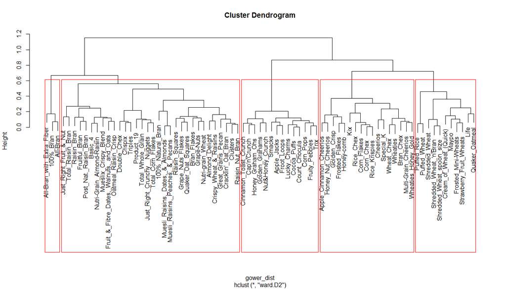

```r
plot(hc_fit_mixed)
rect.hclust(hc_fit_mixed, k = 5, border = "red")
```

#### Quality of Clusters Created

- Shiloutte value - mixed

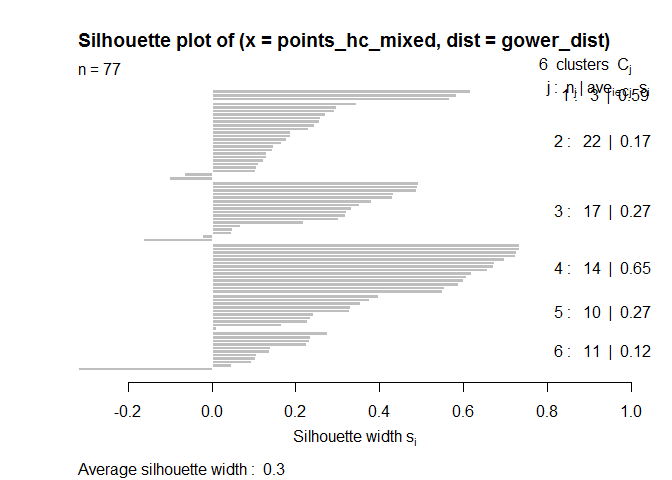

```r
library(cluster)
gower_dist = daisy(x = cereals_data_copy, metric = "gower")

sil_value_hc_mixed = silhouette(points_hc_mixed, dist = gower_dist)
plot(sil_value_hc_mixed)
```

# K-Means Clustering

#### K-Means Clustering procedure

- Build a basic kmeans model with k = 2, using the kmeans() function

```r
set.seed(123)
km_basic <- kmeans(cereals_data, centers = 2, nstart = 20)

str(km_basic)
```

```
## List of 9
##  $ cluster     : Named int [1:77] 2 1 2 2 1 1 1 1 2 2 ...
##   ..- attr(*, "names")= chr [1:77] "100%_Bran" "100%_Natural_Bran" "All-Bran" "All-Bran_with_Extra_Fiber" ...
##  $ centers     : num [1:2, 1:15] 0.432 -0.847 -0.337 0.661 0.182 ...
##   ..- attr(*, "dimnames")=List of 2
##   .. ..$ : chr [1:2] "1" "2"
##   .. ..$ : chr [1:15] "calories" "protein" "fat" "sodium" ...
##  $ totss       : num 961
##  $ withinss    : num [1:2] 478 300
##  $ tot.withinss: num 778
##  $ betweenss   : num 183
##  $ size        : int [1:2] 51 26
##  $ iter        : int 1
##  $ ifault      : int 0
##  - attr(*, "class")= chr "kmeans"
```

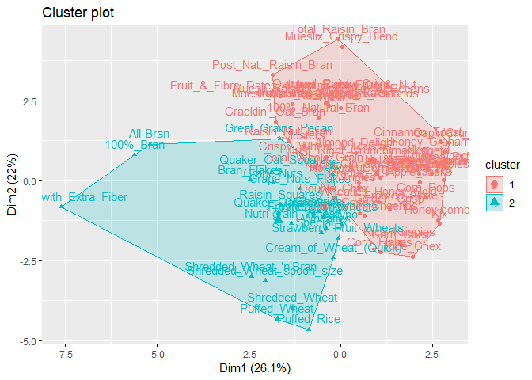

```r
fviz_cluster(km_basic, cereals_data)
```

- The kmeans() function returns a list of 9 objects which include the cluster assignments (“cluster”), cluster centers (“centers”), etc. You can further explore the returned object by calling the str() function on the returned object and going through the documentation
- Let’s now build a screen plot to choose a “k”

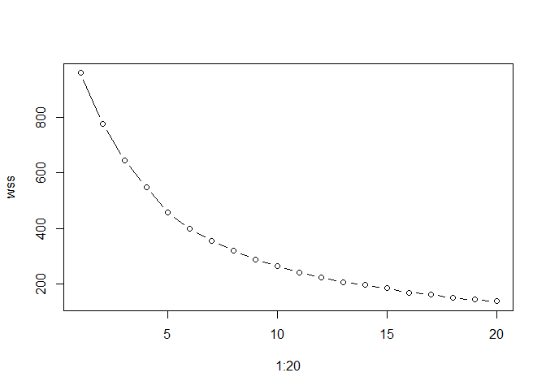

```r
# Initialize wss to 0
wss <- 0

# From 1 upto upto 10 cluster centers, fit the kmeans model
for (i in 1:20) {
  cfit = kmeans(cereals_data, centers = i, nstart = 20)
  # Store the sum of within sum of square
  wss[i] <- sum(cfit$withinss)
}
plot(1:20, wss, type = "b")
```

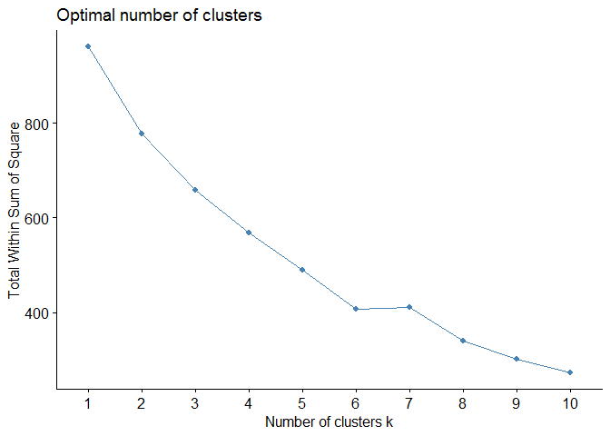

```r
set.seed(123)
fviz_nbclust(cereals_data, kmeans, method = "wss")
```

- Let’s choose k as 6 and cluster the data

```r
set.seed(123)
km_clust <- kmeans(cereals_data, 6)
#Not using 'nstart' parameter for reproducability during cluster stability checking. Initial centriods would be chosen based on set seed here.

# after choosing k as 6, let's store the cluster groupings along with the data in a new data frame
km_points <- km_clust$cluster

# Store the cluster assignments in a new data frame
cereals_clusts_km <- as.data.frame(cbind(km_clust$cluster, cereals_data))

# Look at the head of the data
head(cereals_clusts_km)
```

```
##                           km_clust$cluster   calories    protein
## 100%_Bran                                6 -1.8929836  1.3286071
## 100%_Natural_Bran                        2  0.6732089  0.4151897
## All-Bran                                 6 -1.8929836  1.3286071
## All-Bran_with_Extra_Fiber                6 -2.9194605  1.3286071
## Almond_Delight                           3  0.1599704 -0.4982277
## Apple_Cinnamon_Cheerios                  3  0.1599704 -0.4982277
##                                   fat     sodium       fiber      carbo
## 100%_Bran                 -0.01290349 -0.3539844  3.29284661 -2.5214018
## 100%_Natural_Bran          3.96137277 -1.7257708 -0.06375361 -1.7487994
## All-Bran                  -0.01290349  1.1967306  2.87327158 -2.0063336
## All-Bran_with_Extra_Fiber -1.00647256 -0.2346986  4.97114672 -1.7487994
## Almond_Delight             0.98066557  0.4810160 -0.48332864 -0.2035948
## Apple_Cinnamon_Cheerios    0.98066557  0.2424445 -0.27354112 -1.1049642
##                               sugars     potass   vitamins     weight
## 100%_Bran                 -0.2298253  2.6078060 -0.1453172 -0.1967771
## 100%_Natural_Bran          0.2293718  0.5262315 -1.2642598 -0.1967771
## All-Bran                  -0.4594238  3.1820334 -0.1453172 -0.1967771
## All-Bran_with_Extra_Fiber -1.6074165  3.3255903 -0.1453172 -0.1967771
## Almond_Delight             0.2293718 -0.5813726 -0.1453172 -0.1967771
## Apple_Cinnamon_Cheerios    0.6885689 -0.4068881 -0.1453172 -0.1967771
##                                 cups     rating Shelf1 Shelf2 Shelf3
## 100%_Bran                 -2.1100340  1.8321876      0      0      1
## 100%_Natural_Bran          0.7690100 -0.6180571      0      0      1
## All-Bran                  -2.1100340  1.1930986      0      0      1
## All-Bran_with_Extra_Fiber -1.3795303  3.6333849      0      0      1
## Almond_Delight            -0.3052601 -0.5894990      0      0      1
## Apple_Cinnamon_Cheerios   -0.3052601 -0.9365625      1      0      0
```

```r
colnames(cereals_clusts_km)[1] <- "cluster_km"
```

- We can visualise the clusters by plotting the data using the fviz_cluster() function which plots the points on the first two principal components

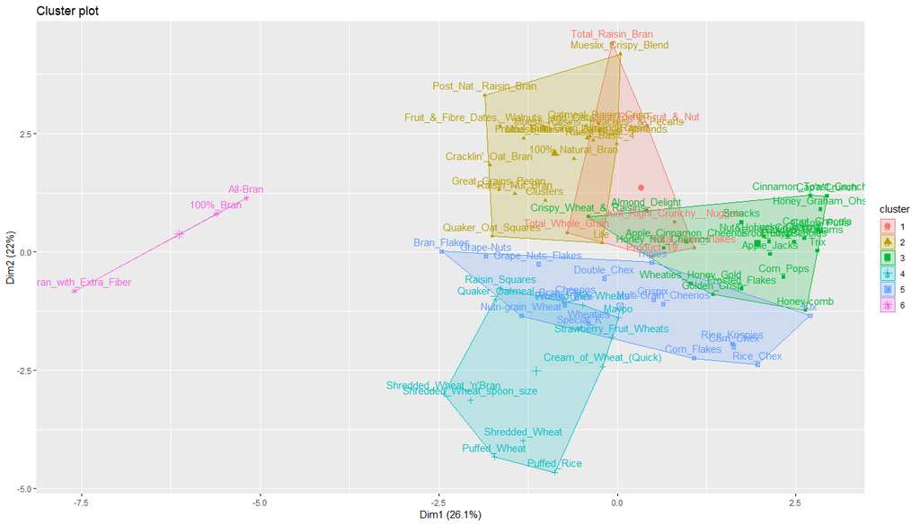

```r
fviz_cluster(km_clust, cereals_data)
```

#### K-Means Cluster Quality

- Shiloutte value

```r
library(cluster)
dist = daisy(x = cereals_data, metric = "euclidean")
```

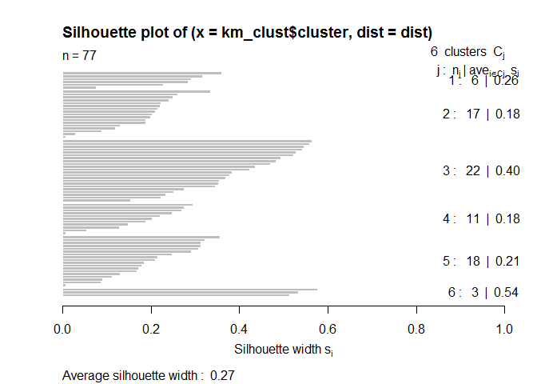

```r
sil_value = silhouette(km_clust$cluster, dist = dist)
plot(sil_value)
```

#### Cluster Stability in kmeans

- Using library(fpc) - clusterboot function

```r
library(fpc)

#Input the scaled cereals_data
#Input the samee seeds used above for reproducability of clustering performed
km_stability <- clusterboot(cereals_data, clustermethod=kmeansCBI,krange = 6, seed = 123, count = FALSE)
km_stability
```

```
## * Cluster stability assessment *
## Cluster method:  kmeans
## Full clustering results are given as parameter result
## of the clusterboot object, which also provides further statistics
## of the resampling results.
## Number of resampling runs:  100
##
## Number of clusters found in data:  6
##
##  Clusterwise Jaccard bootstrap (omitting multiple points) mean:
## [1] 0.4634986 0.6287747 0.9003312 0.6773105 0.6106193 0.7117928
## dissolved:
## [1] 68 33  2 34 35 33
## recovered:
## [1] 28 23 81 43 25 63
```

```r
km_stability$result[1]
```

```
## $result
## K-means clustering with 6 clusters of sizes 6, 17, 22, 11, 18, 3
##
## Cluster means:
##     calories    protein         fat      sodium       fiber      carbo
## 1  0.5021294  0.1107173 -0.17849834  0.58042081 -0.13368278  0.8694640
## 2  0.8543519  0.6301115  1.09755605 -0.08032881  0.42986407 -0.2793401
## 3  0.2066285 -0.9134174  0.03225874  0.12315869 -0.65497296 -0.5898959
## 4 -1.0997968  0.1660759 -0.73549918 -1.80167990 -0.03705338  0.2382566
## 5 -0.1821886  0.1614627 -0.50968803  0.79911139 -0.15699250  0.8980789
## 6 -2.2351425  1.3286071 -0.34409318  0.20268253  3.71242164 -2.0921783
##       sugars      potass   vitamins     weight       cups     rating
## 1 -0.1532925 -0.03603288  3.2115106  0.6892953  0.5899650 -0.3251413
## 2  0.4724761  0.77112261 -0.2111374  0.8391457 -0.6591374 -0.2568016
## 3  0.9912215 -0.72477153 -0.1453172 -0.1967771  0.2084363 -0.9784393
## 4 -1.0631418 -0.05505424 -0.8573716 -0.9036212  0.1088222  1.3797876
## 5 -0.8293326 -0.30320814 -0.1453172 -0.1967771  0.4156945  0.3336558
## 6 -0.7655552  3.03847656 -0.1453172 -0.1967771 -1.8665328  2.2195570
##      Shelf1     Shelf2     Shelf3
## 1 0.0000000 0.00000000 1.00000000
## 2 0.0000000 0.11764706 0.88235294
## 3 0.2727273 0.63636364 0.09090909
## 4 0.3636364 0.36363636 0.27272727
## 5 0.5555556 0.05555556 0.38888889
## 6 0.0000000 0.00000000 1.00000000
##
## Clustering vector:
##                              100%_Bran
##                                      6
##                      100%_Natural_Bran
##                                      2
##                               All-Bran
##                                      6
##              All-Bran_with_Extra_Fiber
##                                      6
##                         Almond_Delight
##                                      3
##                Apple_Cinnamon_Cheerios
##                                      3
##                            Apple_Jacks
```

[output cut: 136 more lines]

```
##                                      5
##                               Wheaties
##                                      5
##                    Wheaties_Honey_Gold
##                                      3
##
## Within cluster sum of squares by cluster:
## [1]  35.44378 113.77594  67.35068  79.04588  99.87212  10.56030
##  (between_SS / total_SS =  57.8 %)
##
## Available components:
##
##  [1] "cluster"      "centers"      "totss"        "withinss"
##  [5] "tot.withinss" "betweenss"    "size"         "iter"
##  [9] "ifault"       "crit"         "bestk"
```

- Analyze the clustering results

```r
groups_km = km_stability$result$partition
groups_km
```

```
##                              100%_Bran
##                                      6
##                      100%_Natural_Bran
##                                      2
##                               All-Bran
##                                      6
##              All-Bran_with_Extra_Fiber
##                                      6
##                         Almond_Delight
##                                      3
##                Apple_Cinnamon_Cheerios
##                                      3
##                            Apple_Jacks
##                                      3
##                                Basic_4
##                                      2
##                              Bran_Chex
##                                      5
##                            Bran_Flakes
##                                      5
##                           Cap'n'Crunch
##                                      3
##                               Cheerios
##                                      5
##                  Cinnamon_Toast_Crunch
##                                      3
##                               Clusters
##                                      2
##                            Cocoa_Puffs
##                                      3
##                              Corn_Chex
##                                      5
##                            Corn_Flakes
##                                      5
##                              Corn_Pops
##                                      3
##                          Count_Chocula
##                                      3
##                     Cracklin'_Oat_Bran
##                                      2
```

[output cut: 99 more lines]

```
##                                      1
##                      Total_Raisin_Bran
##                                      1
##                      Total_Whole_Grain
##                                      1
##                                Triples
##                                      5
##                                   Trix
##                                      3
##                             Wheat_Chex
##                                      5
##                               Wheaties
##                                      5
##                    Wheaties_Honey_Gold
##                                      3
```

- What are the cluster stabiltiy values? Values > 0.85 denote very stable clusters. 0.6 - 0.75 means the clusters show some patterns but needs to be investigated more

```r
#Cluster stability values
km_stability$bootmean
```

```
## [1] 0.4634986 0.6287747 0.9003312 0.6773105 0.6106193 0.7117928
```

- How many times the different clusters were dissolved

```r
#Cluster dissolution rate.
km_stability$bootbrd
```

```
## [1] 68 33  2 34 35 33
```